# Exploratory Data Analysis Report

2023-03-30

## Exploratory Data analysis (EDA)

Analyzing the data sets to summarize their main characteristics of variables, often with visual graphs, without using a statistical model.

### 1. Overview of the data

Understanding the dimensions of the dataset, variable names, overall missing summary and data types of each variables

```r
# Overview of the data
ExpData(data=data,type=1)
# Structure of the data
ExpData(data=data,type=2)
```

**Overview of the data**

| Descriptions | Value |
| --- | --- |
| Sample size (nrow) | 109193 |
| No. of variables (ncol) | 20 |
| No. of numeric/interger variables | 5 |
| No. of factor variables | 0 |
| No. of text variables | 10 |
| No. of logical variables | 0 |
| No. of identifier variables | 0 |
| No. of date variables | 5 |
| No. of zero variance variables (uniform) | 2 |
| %. of variables having complete cases | 100% (20) |

[output cut: 3 more lines]

**Structure of the data**

| Index | Variable_Name | Variable_Type | Sample_n | Missing_Count | Per_of_Missing | No_of_distinct_values |
| --- | --- | --- | --- | --- | --- | --- |
| 1 | insured_id | character | 109193 | 0 | 0 | 63932 |
| 2 | benefit_type | character | 109193 | 0 | 0 | 2 |
| 3 | treatment_start_date | Date | 109193 | 0 | 0 | 244 |
| 4 | treatment_end_date | Date | 109193 | 0 | 0 | 242 |
| 5 | claim_reported_date | Date | 109193 | 0 | 0 | 241 |
| 6 | approved_allowed_amount | numeric | 109193 | 0 | 0 | 373 |
| 7 | medical_service_provider_id | character | 109193 | 0 | 0 | 490 |
| 8 | no_of_days_stayed | numeric | 109193 | 0 | 0 | 84 |
| 9 | primary_diagnosis_code | character | 109193 | 0 | 0 | 6 |
| 10 | primary_procedure_code | character | 109193 | 0 | 0 | 16 |

[output cut: 10 more lines]

**Target variable**

Summary of categorical dependent variable

```
FALSE   fraud Frequency Descriptions
FALSE 1     0    105930        fraud
FALSE 2     1      3263        fraud
```

### 2. Summary of numerical variables

Summary of all numerical variables

Summary statistics when dependent variable is categorical **fraud**. Summary statistics will be splitted into category level

```r
ExpNumStat(data,by="GA",gp=Target,Qnt=seq(0,1,0.1),MesofShape=2,Outlier=TRUE,round=2)
```

| Vname | Group | TN | nNeg | nZero | nPos | NegInf | PosInf | NA_Value | Per_of_Missing | sum | min | max | mean | median | SD | CV | IQR | Skewness | Kurtosis | 0% | 10% | 20% | 30% | 40% | 50% | 60% | 70% | 80% | 90% | … |
| --- | --- | --- | --- | --- | --- | --- | --- | --- | --- | --- | --- | --- | --- | --- | --- | --- | --- | --- | --- | --- | --- | --- | --- | --- | --- | --- | --- | --- | --- | --- |
| approved_allowed_amount | fraud:All | 109193 | 0 | 0 | 109193 | 0 | 0 | 0 | 0 | 1012065262 | 7 | 140875 | 9268.59 | 2400 | 17260.81 | 1.86 | 7000 | 4.06 | 16.49 | 7 | 1800 | 2000 | 2000 | 2300 | 2400 | 7500 | 7500 | 9000 | 15000.0 | … |
| approved_allowed_amount | fraud:0 | 105930 | 0 | 0 | 105930 | 0 | 0 | 0 | 0 | 980630709 | 7 | 140875 | 9257.35 | 2400 | 17228.26 | 1.86 | 7000 | 4.07 | 16.53 | 7 | 1800 | 2000 | 2000 | 2300 | 2400 | 7500 | 7500 | 9000 | 15000.0 | … |
| approved_allowed_amount | fraud:1 | 3263 | 0 | 0 | 3263 | 0 | 0 | 0 | 0 | 31434553 | 500 | 120088 | 9633.64 | 2300 | 18285.01 | 1.90 | 7000 | 3.91 | 15.37 | 500 | 1800 | 2000 | 2300 | 2300 | 2300 | 7040 | 7500 | 10000 | 17560.8 | … |
| birth_date | fraud:All | 109193 | 0 | 7 | 109186 | 0 | 0 | 0 | 0 | 4595778 | 0 | 120 | 42.09 | 41 | 16.96 | 0.40 | 28 | 0.30 | -0.84 | 0 | 22 | 25 | 29 | 34 | 41 | 47 | 52 | 58 | 67.0 | … |
| birth_date | fraud:0 | 105930 | 0 | 7 | 105923 | 0 | 0 | 0 | 0 | 4449564 | 0 | 120 | 42.00 | 41 | 16.94 | 0.40 | 28 | 0.31 | -0.84 | 0 | 22 | 25 | 29 | 34 | 41 | 47 | 52 | 58 | 67.0 | … |
| birth_date | fraud:1 | 3263 | 0 | 0 | 3263 | 0 | 0 | 0 | 0 | 146214 | 1 | 99 | 44.81 | 45 | 17.36 | 0.39 | 29 | 0.11 | -0.99 | 1 | 22 | 26 | 32 | 39 | 45 | 50 | 56 | 62 | 69.0 | … |
| claim_count_pa | fraud:All | 109193 | 0 | 0 | 109193 | 0 | 0 | 0 | 0 | 2809020 | 1 | 142 | 25.73 | 2 | 36.37 | 1.41 | 51 | 1.17 | -0.08 | 1 | 1 | 1 | 1 | 1 | 2 | 4 | 38 | 65 | 89.0 | … |
| claim_count_pa | fraud:0 | 105930 | 0 | 0 | 105930 | 0 | 0 | 0 | 0 | 2738519 | 1 | 142 | 25.85 | 2 | 36.43 | 1.41 | 52 | 1.15 | -0.11 | 1 | 1 | 1 | 1 | 1 | 2 | 4 | 39 | 66 | 89.0 | … |
| claim_count_pa | fraud:1 | 3263 | 0 | 0 | 3263 | 0 | 0 | 0 | 0 | 70501 | 1 | 140 | 21.61 | 2 | 34.25 | 1.59 | 27 | 1.62 | 1.35 | 1 | 1 | 1 | 1 | 2 | 2 | 4 | 16 | 48 | 83.0 | … |
| no_of_days_stayed | fraud:All | 109193 | 0 | 0 | 109193 | 0 | 0 | 0 | 0 | 443660 | 1 | 188 | 4.06 | 3 | 5.17 | 1.27 | 4 | 5.29 | 64.59 | 1 | 1 | 1 | 1 | 2 | 3 | 4 | 5 | 6 | 8.0 | … |

[output cut: 2 more lines]

### 3. Distributions of Numerical variables

- Box plots for all numerical variables vs categorical dependent variable - Bivariate comparision only with categories
  - Quantile-quantile plot(Univariate)
  - Density plot (Univariate)
  - Box plot (Univariate and Bivariate)
  - Scatter plot (Bivariate)

#### Quantile-quantile plot for Numerical variables - Univariate

Quantile-quantile plot for all Numerical variables

```r
ExpOutQQ(data,nlim=4,fname=NULL,Page=c(2,2),sample=sn)
```

```
FALSE $`0`
```

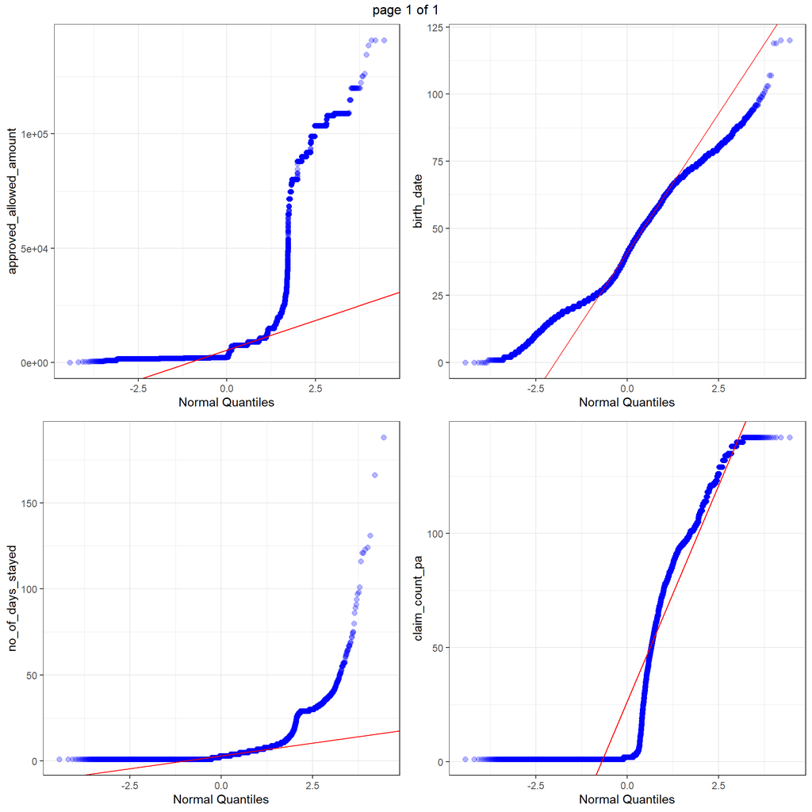

#### Density plots for Numerical variables - Univariate

Density plot for all Numerical variables

```
FALSE $`0`
```

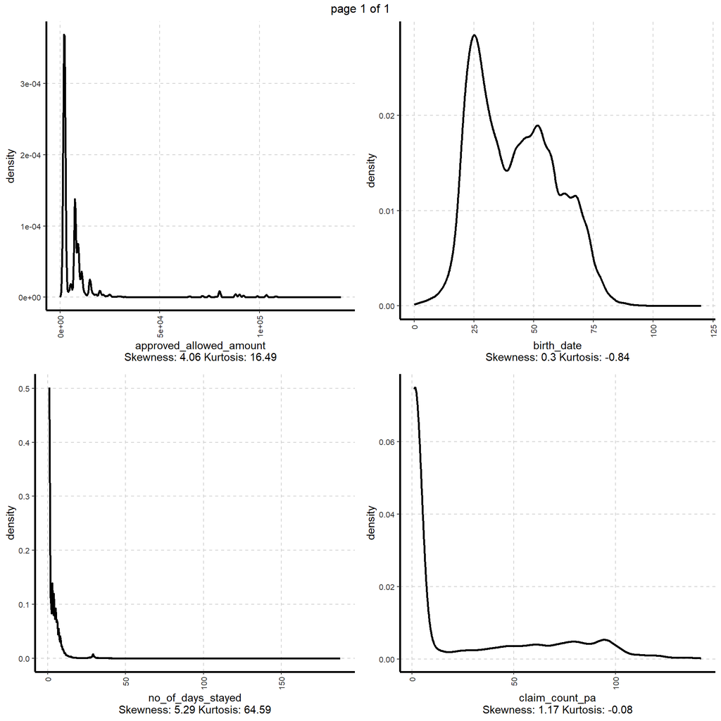

```r
ExpNumViz(data,target=NULL,type=1,Page=c(2,2),theme=theme,sample=sn)
```

#### Scatter plot for all numeric features - Bivariate analysis

```
FALSE $`0`
```

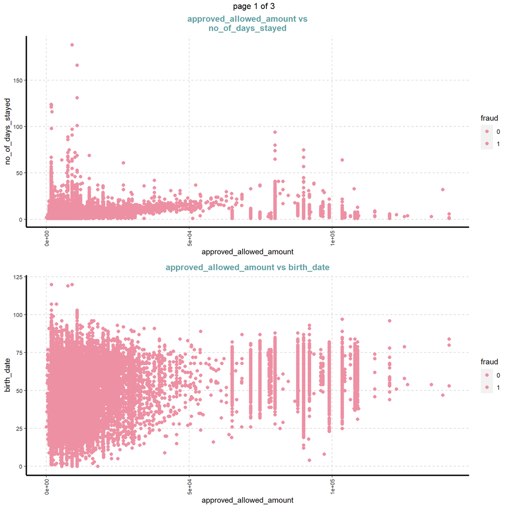

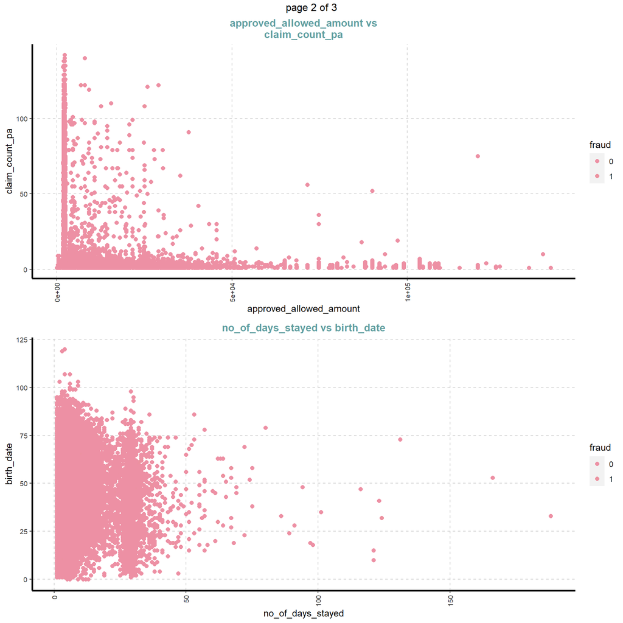

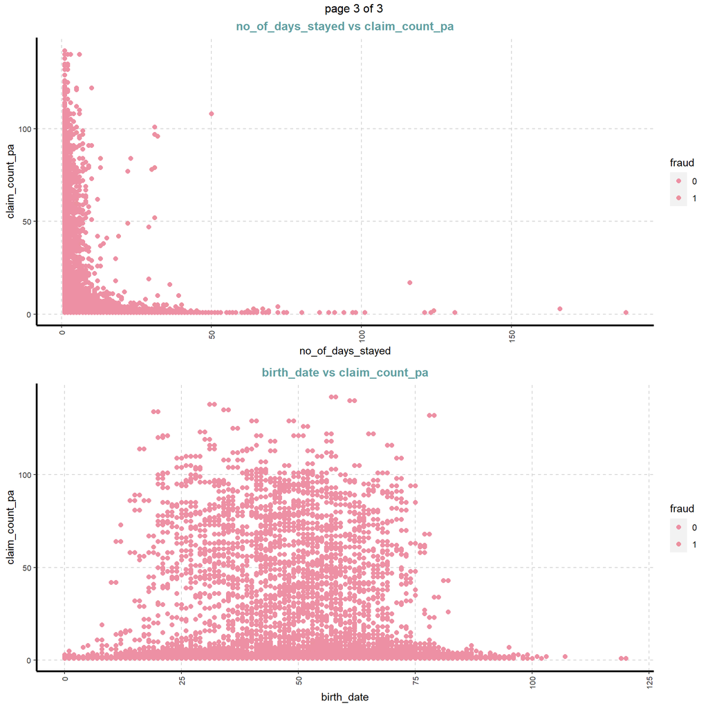

```r
ExpNumViz(data,target=Target,Page=c(2,1),theme=theme,sample=sn,scatter=TRUE)
```

#### Box plots for all numeric features vs categorical dependent variable - Bivariate comparision only with categories

Boxplot for all the numeric attributes by each category of **fraud**

```
FALSE $`0`
```

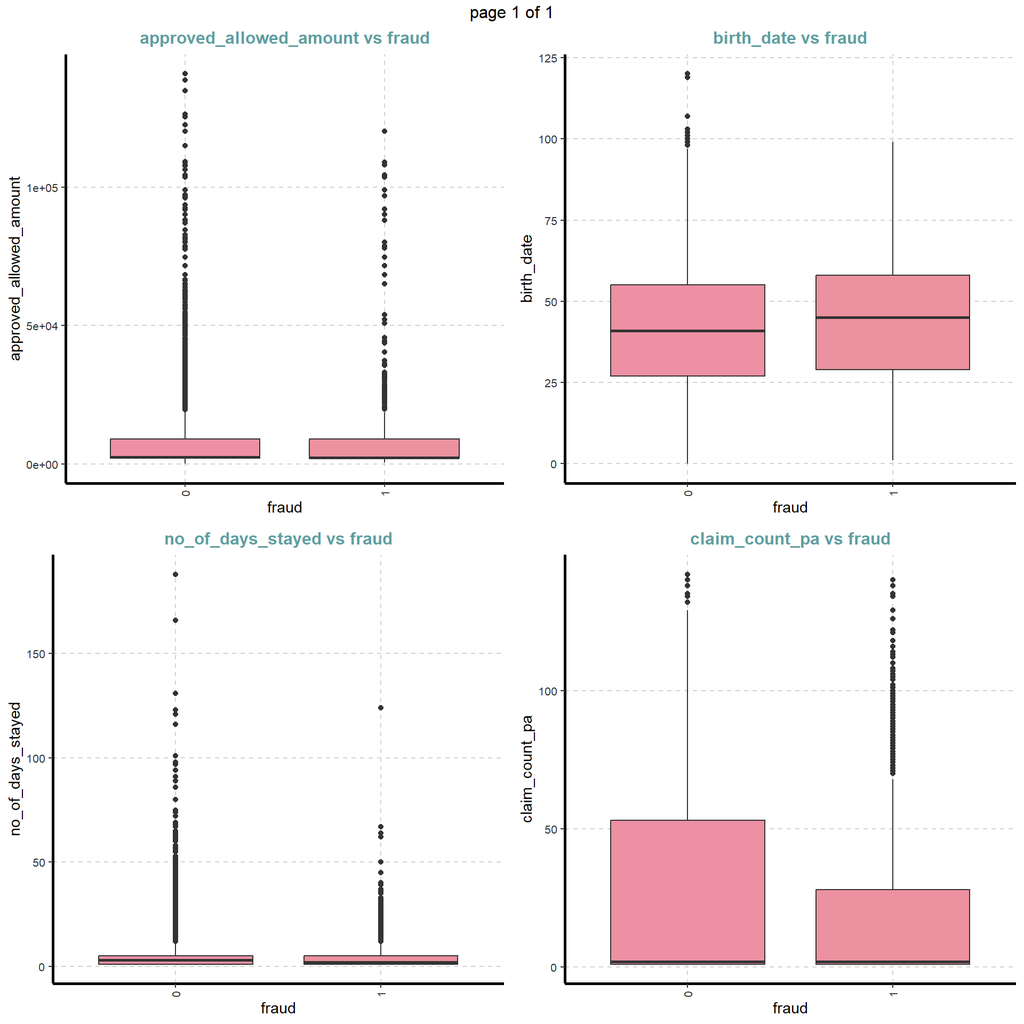

```r
ExpNumViz(data,target=Target,type=2,theme=theme,Page=c(2,2),sample=sn)
```

### 4. Summary of categorical variables

Summary of categorical variable

**Cross tabulation with target variable**

- Custom tables between all categorical independent variables and traget variable **fraud**

```r
ExpCTable(data,Target=Target,margin=1,clim=10,nlim=5,round=2,bin=NULL,per=F)
```

| VARIABLE | CATEGORY | fraud:0 | fraud:1 | TOTAL |
| --- | --- | --- | --- | --- |
| benefit_type | MEDICAL | 32423 | 1245 | 33668 |
| benefit_type | SURGICAL | 73507 | 2018 | 75525 |
| benefit_type | TOTAL | 105930 | 3263 | 109193 |
| primary_diagnosis_code | M1 | 29506 | 1140 | 30646 |
| primary_diagnosis_code | M7 | 2917 | 105 | 3022 |
| primary_diagnosis_code | S1 | 44481 | 1224 | 45705 |
| primary_diagnosis_code | S4 | 8079 | 167 | 8246 |
| primary_diagnosis_code | S5 | 2457 | 53 | 2510 |
| primary_diagnosis_code | U1 | 18490 | 574 | 19064 |
| primary_diagnosis_code | TOTAL | 105930 | 3263 | 109193 |

[output cut: 17 more lines]

**Information Value**

```r
ExpCatStat(data,Target=Target,Label=label,result = "IV",clim=10,nlim=5,Pclass=Rc)
```

| Variable | Class | Out_1 | Out_0 | TOTAL | Per_1 | Per_0 | Odds | WOE | IV | Ref_1 | Ref_0 | Target |
| --- | --- | --- | --- | --- | --- | --- | --- | --- | --- | --- | --- | --- |
| benefit_type.1 | MEDICAL | 32423 | 1245 | 33668 | 0.31 | 0.38 | 0.71 | -0.20 | 0.01 | 0 | 1 | fraud |
| benefit_type.2 | SURGICAL | 73507 | 2018 | 75525 | 0.69 | 0.62 | 1.40 | 0.10 | 0.01 | 0 | 1 | fraud |
| primary_diagnosis_code.1 | M1 | 29506 | 1140 | 30646 | 0.28 | 0.35 | 0.72 | -0.22 | 0.02 | 0 | 1 | fraud |
| primary_diagnosis_code.2 | M7 | 2917 | 105 | 3022 | 0.03 | 0.03 | 0.85 | 0.00 | 0.00 | 0 | 1 | fraud |
| primary_diagnosis_code.3 | S1 | 44481 | 1224 | 45705 | 0.42 | 0.38 | 1.21 | 0.10 | 0.00 | 0 | 1 | fraud |
| primary_diagnosis_code.4 | S4 | 8079 | 167 | 8246 | 0.08 | 0.05 | 1.53 | 0.47 | 0.01 | 0 | 1 | fraud |
| primary_diagnosis_code.5 | S5 | 2457 | 53 | 2510 | 0.02 | 0.02 | 1.44 | 0.00 | 0.00 | 0 | 1 | fraud |
| primary_diagnosis_code.6 | U1 | 18490 | 574 | 19064 | 0.17 | 0.18 | 0.99 | -0.06 | 0.00 | 0 | 1 | fraud |
| hospital_type.1 | Private | 53013 | 1812 | 54825 | 0.50 | 0.56 | 0.80 | -0.12 | 0.01 | 0 | 1 | fraud |
| hospital_type.2 | Public | 52917 | 1451 | 54368 | 0.50 | 0.44 | 1.25 | 0.13 | 0.01 | 0 | 1 | fraud |

[output cut: 40 more lines]

**Statistical test**

```r
ExpCatStat(data,Target=Target,Label=label,result = "Stat",clim=10,nlim=5,Pclass=Rc)
```

| Variable | Target | Unique | Chi-squared | p-value | df | IV Value | Cramers V | Degree of Association | Predictive Power |
| --- | --- | --- | --- | --- | --- | --- | --- | --- | --- |
| benefit_type | fraud | 2 | 84.545 | 0.000 | NA | 0.02 | 0.03 | Very Weak | Not Predictive |
| primary_diagnosis_code | fraud | 6 | 107.293 | 0.000 | NA | 0.03 | 0.03 | Very Weak | Not Predictive |
| hospital_type | fraud | 2 | 38.114 | 0.000 | NA | 0.02 | 0.02 | Very Weak | Not Predictive |
| category | fraud | 7 | 17.248 | 0.037 | NA | 0.00 | 0.01 | Very Weak | Not Predictive |
| gender_code | fraud | 2 | 34.206 | 0.000 | NA | 0.02 | 0.02 | Very Weak | Not Predictive |
| approved_allowed_amount | fraud | 8 | 332.274 | 0.000 | NA | 0.11 | 0.06 | Very Weak | Somewhat Predictive |
| no_of_days_stayed | fraud | 7 | 19.265 | 0.008 | NA | 0.00 | 0.01 | Very Weak | Not Predictive |
| birth_date | fraud | 10 | 106.149 | 0.000 | NA | 0.02 | 0.03 | Very Weak | Not Predictive |
| claim_count_pa | fraud | 6 | 436.891 | 0.000 | NA | 0.09 | 0.06 | Very Weak | Somewhat Predictive |

**Variable importance based on Information value**

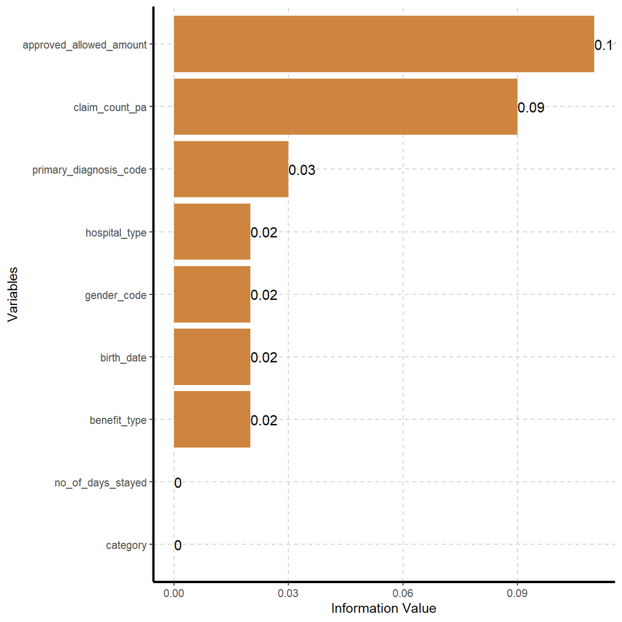

```r
varimp <- ExpCatStat(data,Target=Target,result = "Stat",clim=10,nlim=5,Pclass=Rc,bins=10,plot=TRUE,top=30,Round=2)
```

### 5. Distributions of categorical variables

Graphical representation of all categorical variables

- Bar plot (Univariate)
- Stacked Bar plot (Bivariate)

**Bar plots for all categorical variables**

- Bar plot with vertical or horizontal bars for all categorical variables

```
FALSE $`0`
```

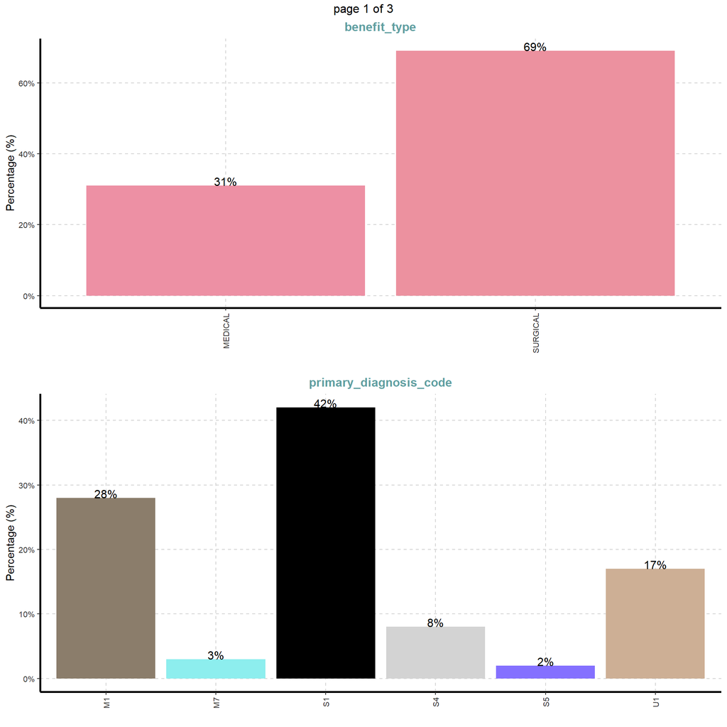

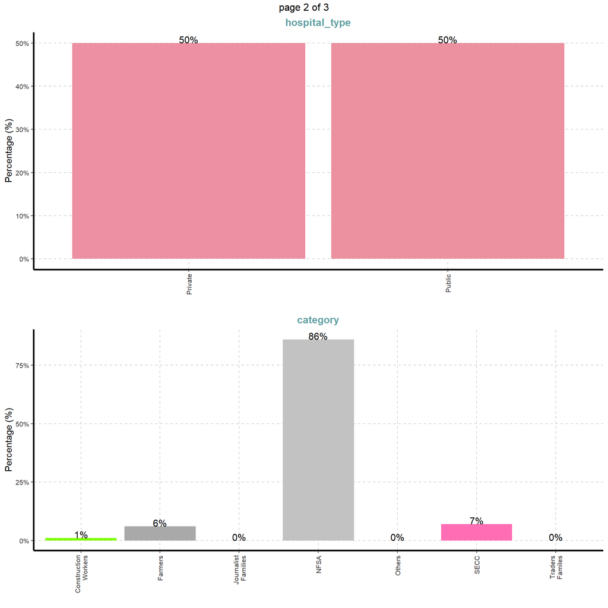

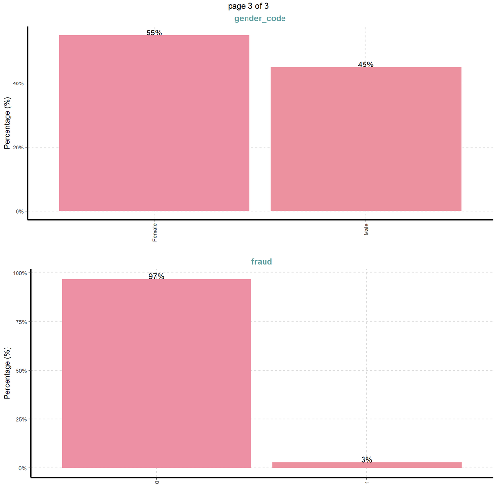

```r
ExpCatViz(data,target=NULL,fname=NULL,clim=10,margin=2,theme=theme,Page = c(2,1),sample=sc)
```

```
FALSE $`0`
```

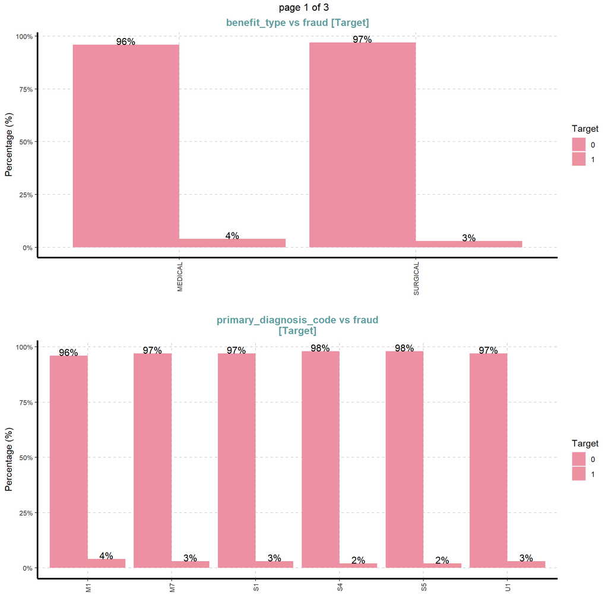

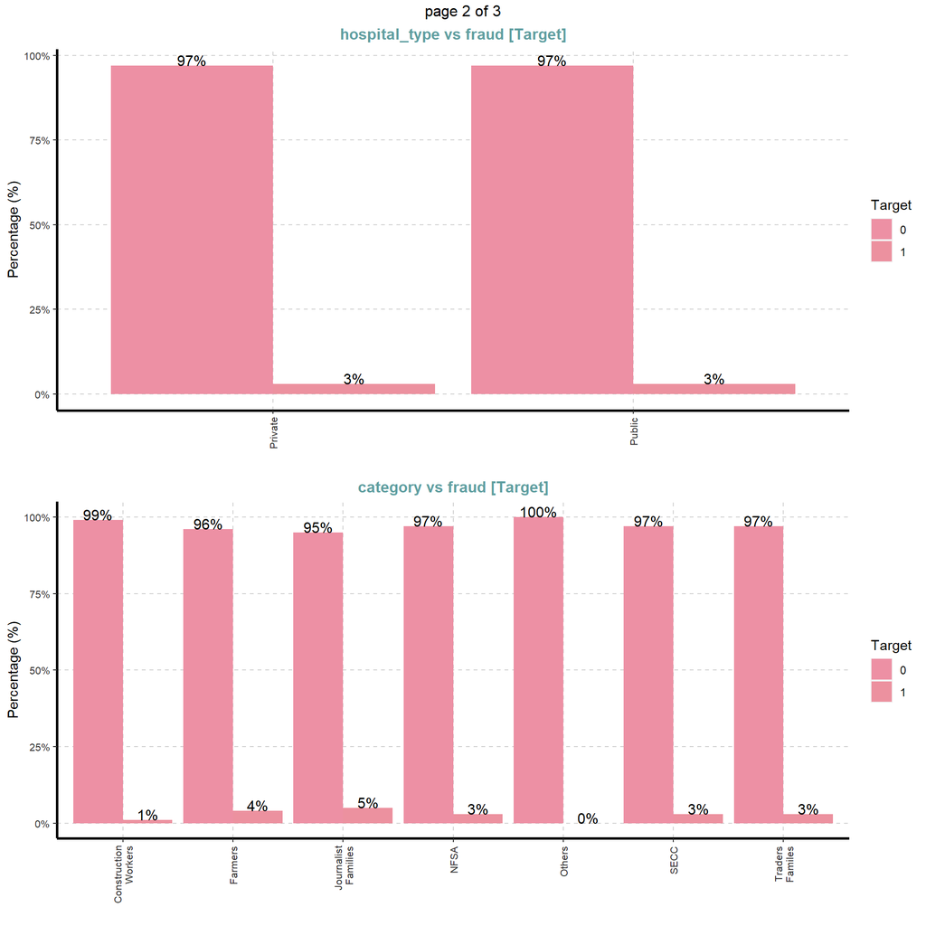

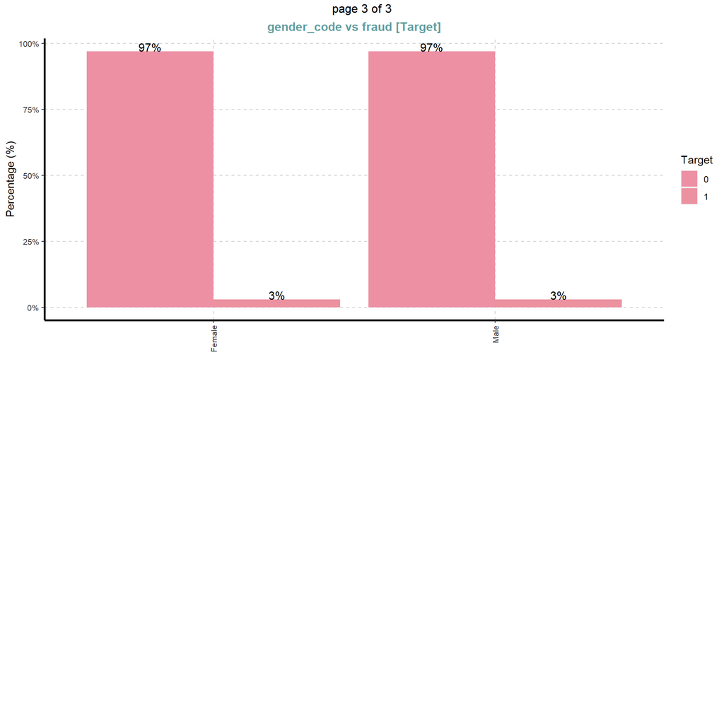

```r
ExpCatViz(data,target=Target,fname=NULL,clim=10,margin=2,theme=theme,Page = c(2,1),sample=sc)
```